# Resposta em Frequência

Sistemas de Controle I — Controle Clássico

Prof. Dr. Raphael Teixeira

Universidade Federal do Pará

## Resposta em Frequência — Conceito

Para um sistema LIT estável com função de transferência $G(s)$, a resposta em **regime permanente** a uma entrada senoidal $u(t)=A\sin(\omega t)$ é também senoidal, de **mesma frequência**, com amplitude e fase alteradas:

$$y_{ss}(t) = A\,|G(j\omega)|\,\sin\!\big(\omega t + \angle G(j\omega)\big)$$

**Ideia central**

A **resposta em frequência** $G(j\omega)$ é obtida substituindo $s=j\omega$ na função de transferência. Ela descreve completamente como o sistema amplifica/atenua e desloca em fase cada frequência $\omega$.

- $|G(j\omega)|$ — **magnitude** (ganho) em função de $\omega$
- $\angle G(j\omega)$ — **fase** em função de $\omega$

## Diagrama de Bode

O **diagrama de Bode** representa $G(j\omega)$ em **dois gráficos** com eixo de frequência **logarítmico**:

- **Magnitude**: $20\log_{10}|G(j\omega)|$ em decibéis (dB) vs. $\log_{10}\omega$
- **Fase**: $\angle G(j\omega)$ em graus vs. $\log_{10}\omega$

**Por que log-log/log-linear?**

Fatores de $G(j\omega)$ em **produto** (polos, zeros, ganho) tornam-se **somas** em dB e em fase — cada fator contribui uma assíntota simples que se **soma** graficamente às demais.

## Assíntotas de Bode — Fatores Básicos

[output not shown]

**Note**

A frequência $\omega=p$ (ou $z$) é a **frequência de canto** (*corner frequency*) — no diagrama assintótico, o erro máximo em relação à curva real é de $\approx3$ dB nesse ponto.

## Construindo o Diagrama Assintótico

**Procedimento:**

1. Escreva $G(j\omega)$ como produto de fatores básicos (ganho, polos/zeros na origem, polos/zeros reais, pares complexos)
2. Identifique as **frequências de canto** de cada fator (ordene-as)
3. Comece a assíntota de magnitude com a inclinação do(s) fator(es) de baixa frequência (ganho + polos/zeros na origem)
4. A cada frequência de canto, **some** a inclinação do fator correspondente ($-20$ dB/década por polo, $+20$ dB/década por zero)
5. Para a fase, some as contribuições assintóticas (ou exatas) de cada fator

## Exemplo — Diagrama de Bode

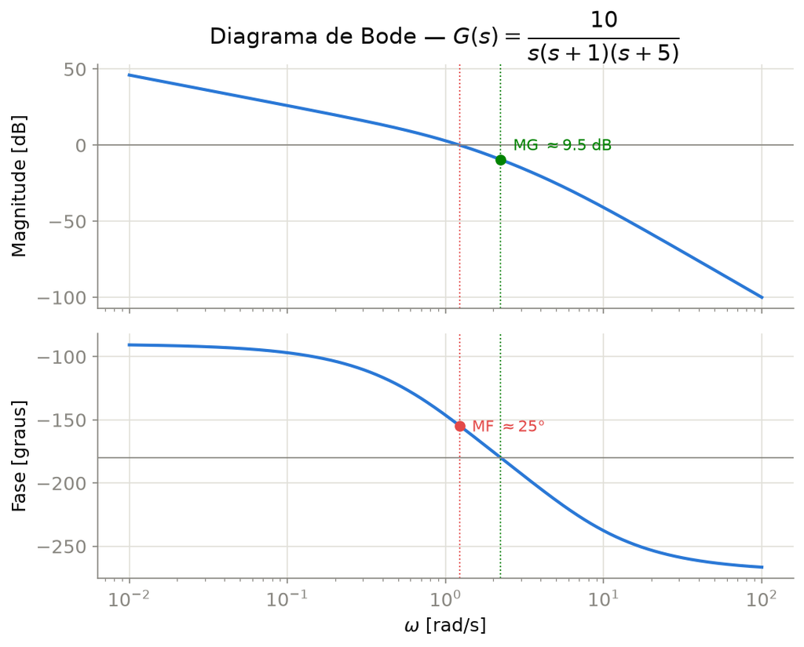

Diagrama de Bode de $G(s)=10/[s(s+1)(s+5)]$, com margens de ganho e fase

- Polo na origem: $-20$ dB/dec desde baixas frequências, fase partindo de $-90°$
- Frequências de canto em $\omega=1$ e $\omega=5$ rad/s (polos reais): inclinação cai para $-40$ e depois $-60$ dB/dec

## Margens de Estabilidade

Para sistemas de **fase mínima** (sem polos/zeros no semiplano direito), a estabilidade da malha fechada pode ser avaliada diretamente no Bode de malha aberta $G(j\omega)H(j\omega)$:

**Margem de Ganho (MG)**

$$\text{MG (dB)} = -20\log_{10}\big|G(j\omega_{gc})H(j\omega_{gc})\big|$$
onde $\omega_{gc}$ é a **frequência de cruzamento de fase** ($\angle G H = -180°$). Quanto o ganho pode aumentar antes de instabilizar.

**Margem de Fase (MF)**

$$\text{MF} = 180° + \angle G(j\omega_{pc})H(j\omega_{pc})$$
onde $\omega_{pc}$ é a **frequência de cruzamento de ganho** ($|GH|=1=0$ dB). Quanto de atraso de fase adicional o sistema tolera antes de instabilizar.

## Interpretando as Margens no Exemplo

No diagrama de Bode do slide anterior, $G(s) = \dfrac{10}{s(s+1)(s+5)}$:

- $\omega_{pc} \approx 1{,}23$ rad/s (onde $|G|=0$ dB) $\implies$ **MF $\approx 25°$**
- $\omega_{gc} \approx 2{,}24$ rad/s (onde $\angle G=-180°$) $\implies$ **MG $\approx 9{,}5$ dB**

**Regras práticas de projeto**

Margens **positivas** $\implies$ malha fechada **estável**. Valores usuais de projeto: **MF entre $30°$ e $60°$**, **MG maior que $6$ dB** — margens pequenas (como MF $\approx25°$ acima) indicam sistema estável mas com pouca robustez e resposta transitória oscilatória.

## Relação entre Margem de Fase e Amortecimento

Para um sistema de malha aberta tipo dominante de 2ª ordem, existe a aproximação clássica:

$$\zeta \approx \frac{\text{MF}}{100}, \qquad \text{válida para } \text{MF} \lesssim 60°$$

| MF | $\zeta$ aprox. | $M_p$ aprox. |
| --- | --- | --- |
| $20°$ | $0{,}2$ | $53\%$ |
| $40°$ | $0{,}4$ | $25\%$ |
| $60°$ | $0{,}6$ | $9\%$ |
| $70°$ | $0{,}7$ | $5\%$ |

**Note**

Essa relação permite **traduzir** uma especificação de sobressinal (domínio do tempo, Aula 4) em uma especificação de margem de fase (domínio da frequência) — ponte fundamental para o projeto de controladores por resposta em frequência.

## Banda Passante e Velocidade de Resposta

A **banda passante** $\omega_{BW}$ é a frequência em que $|T(j\omega)|$ (malha fechada) cai $3$ dB abaixo do valor em $\omega=0$.

**Relação aproximada (2ª ordem)**

$$\omega_{BW} \approx \omega_n\sqrt{(1-2\zeta^2)+\sqrt{4\zeta^4-4\zeta^2+2}}$$
Para $\zeta$ típico ($0{,}4$–$0{,}8$): $\omega_{BW} \approx (1\text{ a }1{,}5)\,\omega_n$.

- Quanto **maior** a banda passante, **mais rápida** a resposta transitória (menor $t_r$, menor $t_s$) — mas também maior sensibilidade a ruído de medição em alta frequência

## Critério de Nyquist (Visão Geral)

O critério de Bode (margens) **pressupõe** sistema de fase mínima. Para o caso geral (incluindo polos de malha aberta no semiplano direito), usa-se o **critério de Nyquist**:

**Critério de Nyquist**

$$Z = N + P$$
onde $P$ é o número de polos de malha aberta no SPD, $N$ é o número de envolvimentos **horários** do ponto $-1$ pelo diagrama de Nyquist de $G(j\omega)H(j\omega)$, e $Z$ é o número de polos de malha fechada no SPD. Estabilidade $\iff Z=0$.

**Tip**

O diagrama de Nyquist é o gráfico de $G(j\omega)H(j\omega)$ no **plano complexo** (parte real vs. imaginária), percorrendo $\omega$ de $-\infty$ a $+\infty$. As margens de ganho e fase têm interpretação geométrica direta como distâncias ao ponto $-1$.

## Resumo: Domínio do Tempo vs. Frequência

| Domínio do Tempo | Domínio da Frequência |
| --- | --- |
| Polos dominantes ($\zeta,\omega_n$) | Margem de fase, banda passante |
| Sobressinal $M_p$ | Margem de fase (aprox. $\zeta\approx\text{MF}/100$) |
| Tempo de acomodação $t_s$ | Banda passante (inversamente relacionada) |
| Erro de regime permanente | Ganho em baixa frequência ($K_p$, $K_v$, $K_a$) |
| Routh-Hurwitz | Critério de Nyquist |